# The effects of microplastics on reproduction

Nicole Grechi, Michael J Noonan, Marcia de Almeida Monterio Melo Ferraz

This script was last updated on August 27, 2022.

# Background

This file walks through the statistical analyses used to assess the effects of microplastics on sperm and oocyte function *in vitro*.

### Packages

The packages used in these analyses are detailed below. Package versions are included at the end of this document.

```r
# Packages used in the analyses
library(lme4)
library(MASS)
library(multcomp)
library(MuMIn)
library(gtsummary)
```

```r
library(ggplot2)
library(knitr)
library(ggrepel)
library(VennDiagram)
```

# Sperm

The first step was to assess the effects of microplastics (MPs) exposure on sperm This was done using generalised linear regression models with binomial error distributions to determine the extent to which exposure to MPs influenced motility and acrosomal integrity.

## Effects of MPs on motility

The first step was to import the sperm motility data and carry out some basic data carpentry in order to get the data in the correct format for analysis.

```r
# Import the sperm motility data
data <- read.csv("Data/Motility.csv")

# Rename a few variables
data$Dead <- data$Total - data$Motile
data$Motile <- data$Motile/data$Total
data$Dead <- data$Dead/data$Total

# Convert the arbitrary time points to minutes since start of the experiment
data[which(data$Time == 0.5),"Time"] <- 30
data[which(data$Time == 1),"Time"] <- 60
data[which(data$Time == 1.5),"Time"] <- 90
data[which(data$Time == 2),"Time"] <- 120

# Convert time to a factor for plotting purposes only
data$Time2 <- as.factor(data$Time)

# Rename the groups
data[which(data$Treatment == "CT"),"Treatment"] <- "Control"
data[which(data$Treatment == "B0.3"),"Treatment"] <- "MP_0.3"
data[which(data$Treatment == "B1.1"),"Treatment"] <- "MP_1.1"
data[which(data$Treatment == "B0.05"),"Treatment"] <- "MP_0.05"
data[which(data$Treatment == "B0.1"),"Treatment"] <- "MP_0.1"

# Drop a time point with questionable data
data <- data[which(data$Time !=30),]
```

After importing and preparing the sperm motility data, the next step was to obtain some basic summary statistics about the data.

```r
# Mean motility by treatment and time
means <- aggregate(Motile ~ Time*Treatment, data = data, FUN = "mean")

# SDs by treatment and time
sds <- aggregate(Motile ~ Time*Treatment, data = data, FUN = "sd")

means$SD <- sds$Motile
names(means)[3] <- c("Mean")

kable(means, format="markdown", digits = 3, align = "c", caption = "Basic summary statistics on the sperm motility data.")
```

Basic summary statistics on the sperm motility data.

| Time | Treatment | Mean | SD |
| --- | --- | --- | --- |
| 0 | Control | 0.735 | 0.137 |
| 60 | Control | 0.539 | 0.147 |
| 90 | Control | 0.454 | 0.200 |
| 120 | Control | 0.418 | 0.173 |
| 0 | MP_0.05 | 0.771 | 0.125 |
| 60 | MP_0.05 | 0.605 | 0.153 |
| 90 | MP_0.05 | 0.451 | 0.175 |
| 120 | MP_0.05 | 0.272 | 0.176 |
| 0 | MP_0.1 | 0.771 | 0.125 |
| 60 | MP_0.1 | 0.558 | 0.136 |
| 90 | MP_0.1 | 0.418 | 0.130 |
| 120 | MP_0.1 | 0.329 | 0.204 |
| 0 | MP_0.3 | 0.700 | 0.127 |
| 60 | MP_0.3 | 0.455 | 0.153 |
| 90 | MP_0.3 | 0.374 | 0.189 |
| 120 | MP_0.3 | 0.368 | 0.177 |
| 0 | MP_1.1 | 0.700 | 0.127 |
| 60 | MP_1.1 | 0.456 | 0.169 |
| 90 | MP_1.1 | 0.413 | 0.123 |
| 120 | MP_1.1 | 0.328 | 0.166 |

Next, we used generalised linear regression models to assess the effects of MP exposure on sperm motility. For these analyses all models had a binomial error distribution to account for the fact that the data were proportions, ranging between 0 – 1. We also included random intercepts to account for differences between the different bulls from which the sperm came, and any differences across replicates.

```r
# Fit the various logistic regression models
NULL_MOD <- glmer(Motile ~ 1 + (1|bull) + (1|Replicate),
                  family = binomial,
                  data = data)

TIME_MOD <- glmer(Motile ~ Time + (1|bull) + (1|Replicate),
                  family = binomial,
                  data = data)

TIME_TREAT_MOD <- glmer(Motile ~ Time + Treatment + (1|bull) + (1|Replicate),
                        family = binomial,
                        data = data)

#AICc based model selection to identify the best fit model
AICc(NULL_MOD, TIME_MOD, TIME_TREAT_MOD)
```

```
##                df     AICc
## NULL_MOD        3 285.1816
## TIME_MOD        4 221.6489
## TIME_TREAT_MOD  8 226.1324
```

```r
#Summary of the model that includes the effects of time and treatment
tbl_regression(TIME_TREAT_MOD, intercept= T) %>% add_global_p(keep = T)
```

| **Characteristic** | **log(OR)**<sup>1</sup> | **95% CI**<sup>1</sup> | **p-value** |
| --- | --- | --- | --- |
| (Intercept) | 3.0 | 1.8, 4.2 | <0.001 |
| Time | -0.03 | -0.04, -0.02 | <0.001 |
| Treatment |  |  | 0.4 |
| Control | — | — |  |
| MP_0.05 | -0.18 | -1.5, 1.1 | 0.8 |
| MP_0.1 | -0.66 | -2.0, 0.64 | 0.3 |
| MP_0.3 | -0.60 | -1.5, 0.34 | 0.2 |
| MP_1.1 | -0.87 | -1.8, 0.07 | 0.070 |

<sup>1</sup> OR = Odds Ratio, CI = Confidence Interval

These results indicate that although all of the MP exposure treatments tended to have lower motility than the control, these effects were not statistically significant. A figure of the results is shown below. Note: For the sake of brevity, the code used to generate the figure are not shown here.

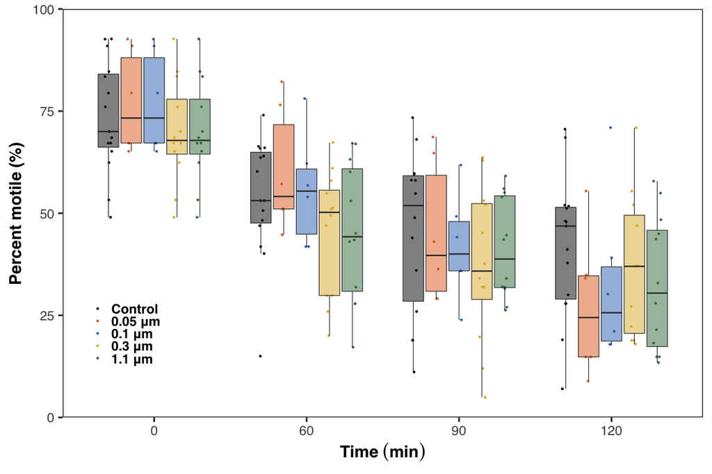

Figure S1 Boxplots depicting sperm motility over time as a function of microplastics treatment.

## Effects of MPs on acrosomal integrity

The first step was to import the sperm acrosomal integrity data and carry out some basic data carpentry in order to get the data in the correct format for analysis.

```r
# Import the sperm motility data
data <- read.csv("Data/Acrosome.csv")

# Scale percentages between 0-1 for the binomial model
data$acrosome2 <- data$acrosome/100

# Convert the arbitrary time points to minutes since start of the experiment
data[which(data$Time == 0.5),"Time"] <- 30
data[which(data$Time == 1),"Time"] <- 60
data[which(data$Time == 1.5),"Time"] <- 90
data[which(data$Time == 2),"Time"] <- 120

# Convert time to a factor for plotting purposes only
data$Time2 <- as.factor(data$Time)

# Rename the groups
data[which(data$Treatment == "CT"),"Treatment"] <- "Control"
data[which(data$Treatment == "B0.3"),"Treatment"] <- "MP_0.3"
data[which(data$Treatment == "B1.1"),"Treatment"] <- "MP_1.1"
data[which(data$Treatment == "B0.05"),"Treatment"] <- "MP_0.05"
data[which(data$Treatment == "B0.1"),"Treatment"] <- "MP_0.1"

# Drop a time point with questionable data
data <- data[which(data$Time !=30),]
```

After importing and preparing the sperm acrosomal integrity data, the next step was to obtain some basic summary statistics about the data.

```r
# Mean acrosomal integrity by treatment and time
means <- aggregate(acrosome2 ~ Time*Treatment, data = data, FUN = "mean")

# SDs by treatment and time
sds <- aggregate(acrosome2 ~ Time*Treatment, data = data, FUN = "sd")

means$SD <- sds$acrosome2
names(means)[3] <- c("Mean")

kable(means, format="markdown", digits = 3, align = "c", caption = "Basic summary statistics on the sperm acrosomal integrity data.")
```

Basic summary statistics on the sperm acrosomal integrity data.

| Time | Treatment | Mean | SD |
| --- | --- | --- | --- |
| 0 | Control | 0.922 | 0.054 |
| 60 | Control | 0.828 | 0.055 |
| 90 | Control | 0.772 | 0.091 |
| 120 | Control | 0.728 | 0.127 |
| 0 | MP_0.05 | 0.946 | 0.020 |
| 60 | MP_0.05 | 0.778 | 0.098 |
| 90 | MP_0.05 | 0.719 | 0.215 |
| 120 | MP_0.05 | 0.655 | 0.235 |
| 0 | MP_0.1 | 0.946 | 0.020 |
| 60 | MP_0.1 | 0.710 | 0.139 |
| 90 | MP_0.1 | 0.666 | 0.185 |
| 120 | MP_0.1 | 0.606 | 0.191 |
| 0 | MP_0.3 | 0.797 | 0.163 |
| 60 | MP_0.3 | 0.475 | 0.303 |
| 90 | MP_0.3 | 0.505 | 0.274 |
| 120 | MP_0.3 | 0.494 | 0.242 |
| 0 | MP_1.1 | 0.797 | 0.163 |
| 60 | MP_1.1 | 0.457 | 0.397 |
| 90 | MP_1.1 | 0.398 | 0.394 |
| 120 | MP_1.1 | 0.318 | 0.362 |

Next we used generalised linear regression models to assess the effects of MP exposure on acrosomal integrity. For these analyses all models had a binomial error distribution to account for the fact that the data were percentages, ranging between 0 – 1. We also included random intercepts to account for differences between the different bulls from which the sperm came, and any differences across replicates.

```r
# Fit the various logistic regression models
NULL_MOD <- glmer(acrosome2 ~ 1 + (1|bull) + (1|Replicate),
                  family = binomial,
                  data = data)

TIME_MOD <- glmer(acrosome2 ~ Time + (1|bull) + (1|Replicate),
                  family = binomial,
                  data = data)

TIME_TREAT_MOD <- glmer(acrosome2 ~ Time + Treatment + (1|bull) + (1|Replicate),
                        family = binomial,
                        data = data)

#AICc based model selection to identify the best fit model
AICc(NULL_MOD, TIME_MOD, TIME_TREAT_MOD)
```

```
##                df     AICc
## NULL_MOD        3 80.80280
## TIME_MOD        4 70.67289
## TIME_TREAT_MOD  8 60.35450
```

```r
#Summary of the model that includes the effects of time and treatment
tbl_regression(TIME_TREAT_MOD, intercept= T) %>% add_global_p(keep = T)
```

| **Characteristic** | **log(OR)**<sup>1</sup> | **95% CI**<sup>1</sup> | **p-value** |
| --- | --- | --- | --- |
| (Intercept) | 23 | 23, 23 | <0.001 |
| Time | -0.05 | -0.06, -0.03 | <0.001 |
| Treatment |  |  | <0.001 |
| Control | — | — |  |
| MP_0.05 | -17 | -17, -17 | <0.001 |
| MP_0.1 | -18 | -18, -18 | <0.001 |
| MP_0.3 | -20 | -20, -20 | <0.001 |
| MP_1.1 | -20 | -20, -20 | <0.001 |

<sup>1</sup> OR = Odds Ratio, CI = Confidence Interval

These results indicate that all of the sperm cells exposed to MPs tended to have significantly lower acrosomal integrity than the control .A figure of the results is shown below. Note: Here again the code used to generate the figure are not shown.

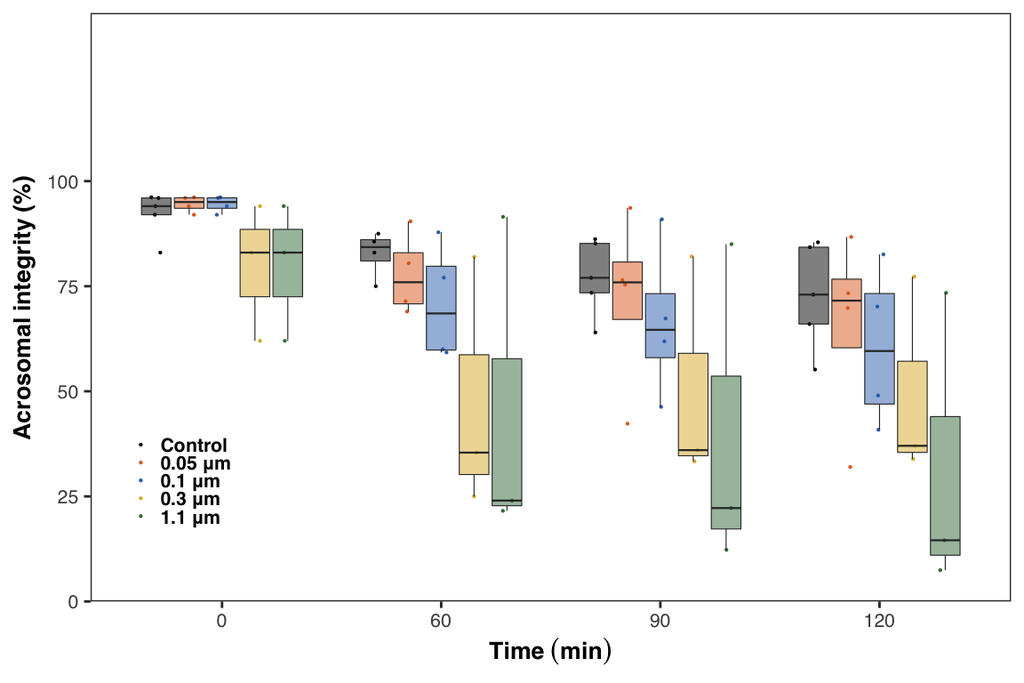

Figure S2 Boxplots depicting sperm acrosomal integrity over time as a function of microplastics treatment.

## Effects of MPs on oxidative stress

The first step was to import the sperm oxidative stress data and carry out some basic data carpentry in order to get the data in the correct format for analysis.

```r
# Import the sperm motility data
data <- read.csv("Data/CR.csv")

# Scale percentages between 0-1 for the binomial model
data$CR2 <- data$CR/100

# Convert the arbitrary time points to minutes since start of the experiment
data[which(data$Time == 0.5),"Time"] <- 30
data[which(data$Time == 1),"Time"] <- 60
data[which(data$Time == 1.5),"Time"] <- 90
data[which(data$Time == 2),"Time"] <- 120
data[which(data$Time == 3),"Time"] <- 180

# Convert time to a factor for plotting purposes only
data$Time2 <- as.factor(data$Time)

# Rename the groups
data[which(data$Treatment == "CT"),"Treatment"] <- "Control"
data[which(data$Treatment == "CT+"),"Treatment"] <- "Control_Positive"
data[which(data$Treatment == "b0.3"),"Treatment"] <- "MP_0.3"
data[which(data$Treatment == "b1.1"),"Treatment"] <- "MP_1.1"
data[which(data$Treatment == "b0.05"),"Treatment"] <- "MP_0.05"
data[which(data$Treatment == "b0.1"),"Treatment"] <- "MP_0.1"
data$Treatment <- as.factor(data$Treatment)
```

After importing and preparing the oxidative stress data, the next step was to obtain some basic summary statistics.

```r
# Mean acrosomal integrity by treatment and time
means <- aggregate(CR2 ~ Time*Treatment, data = data, FUN = "mean")

# SDs by treatment and time
sds <- aggregate(CR2 ~ Time*Treatment, data = data, FUN = "sd")

means$SD <- sds$CR2
names(means)[3] <- c("Mean")

kable(means, format="markdown", digits = 3, align = "c", caption = "Basic summary statistics on the sperm oxidative stress data.")
```

Basic summary statistics on the sperm oxidative stress data.

| Time | Treatment | Mean | SD |
| --- | --- | --- | --- |
| 30 | Control | 0.033 | 0.038 |
| 60 | Control | 0.077 | 0.065 |
| 90 | Control | 0.077 | 0.067 |
| 120 | Control | 0.093 | 0.075 |
| 180 | Control | 0.078 | 0.074 |
| 30 | Control_Positive | 0.138 | 0.142 |
| 60 | Control_Positive | 0.259 | 0.151 |
| 90 | Control_Positive | 0.284 | 0.135 |
| 120 | Control_Positive | 0.239 | 0.127 |
| 180 | Control_Positive | 0.189 | 0.136 |
| 30 | MP_0.05 | 0.244 | 0.257 |
| 60 | MP_0.05 | 0.201 | 0.123 |
| 90 | MP_0.05 | 0.247 | 0.151 |
| 120 | MP_0.05 | 0.276 | 0.161 |
| 180 | MP_0.05 | 0.255 | 0.158 |
| 30 | MP_0.1 | 0.198 | 0.223 |
| 60 | MP_0.1 | 0.189 | 0.026 |
| 90 | MP_0.1 | 0.219 | 0.142 |
| 120 | MP_0.1 | 0.248 | 0.155 |
| 180 | MP_0.1 | 0.200 | 0.222 |
| 30 | MP_0.3 | 0.266 | 0.205 |
| 60 | MP_0.3 | 0.195 | 0.125 |
| 90 | MP_0.3 | 0.168 | 0.097 |
| 120 | MP_0.3 | 0.232 | 0.167 |
| 180 | MP_0.3 | 0.132 | 0.124 |
| 30 | MP_1.1 | 0.195 | 0.132 |
| 60 | MP_1.1 | 0.225 | 0.233 |
| 90 | MP_1.1 | 0.188 | 0.193 |
| 120 | MP_1.1 | 0.169 | 0.036 |
| 180 | MP_1.1 | 0.127 | 0.076 |

After an initial visual verification, we found that we needed to assess whether there was any evidence of under/overdispersion in the data. This was done by estimating the dispersion parameter of the data.

```r
#Test if the data are under/overdispersed
quasi_binom <- glm(CR2 ~ Treatment + Time, data = data, family=quasibinomial)
summary(quasi_binom)
```

```
##
## Call:
## glm(formula = CR2 ~ Treatment + Time, family = quasibinomial,
##     data = data)
##
## Deviance Residuals:
##      Min        1Q    Median        3Q       Max
## -0.71691  -0.27851  -0.03438   0.22866   0.69330
##
## Coefficients:
##                             Estimate Std. Error t value Pr(>|t|)
## (Intercept)               -2.5212688  0.3683510  -6.845 6.26e-10 ***
## TreatmentControl_Positive  1.3066930  0.3795403   3.443 0.000842 ***
## TreatmentMP_0.05           1.4356696  0.3788841   3.789 0.000258 ***
## TreatmentMP_0.1            1.2477669  0.3833707   3.255 0.001549 **
## TreatmentMP_0.3            1.1873119  0.3849349   3.084 0.002637 **
## TreatmentMP_1.1            1.0521190  0.4023667   2.615 0.010308 *
## Time                      -0.0004317  0.0016278  -0.265 0.791405
## ---
## Signif. codes:  0 '***' 0.001 '**' 0.01 '*' 0.05 '.' 0.1 ' ' 1
##
## (Dispersion parameter for quasibinomial family taken to be 0.1114208)
##
##     Null deviance: 14.536  on 106  degrees of freedom
## Residual deviance: 12.284  on 100  degrees of freedom
## AIC: NA
##
## Number of Fisher Scoring iterations: 5
```

These results indicate that the dispersion parameter was 0.111, suggesting the data were extremely underdispersed.

Next we used generalised linear regression models to assess the effects of MP exposure on oxidative stress. For these analyses all models had a binomial error distribution to account for the fact that the data were percentages, ranging between 0 – 1. We also included random intercepts to account for differences between the different bulls from which the sperm came, and any differences across replicates.

```r
fit.quasi.binom <- MASS::glmmPQL(CR2 ~ Treatment + Time,
                                 random = ~ 1|Replicate + 1|Bull,
                                 family=quasibinomial,
                                 data = data)

#Summary of the model that includes the effects of time and treatment
tbl_regression(fit.quasi.binom, intercept= T) %>% add_global_p(keep = T)
```

| **Characteristic** | **Beta** | **95% CI**<sup>1</sup> | **p-value** |
| --- | --- | --- | --- |
| (Intercept) | -2.6 | -3.6, -1.7 | <0.001 |
| Treatment |  |  | <0.001 |
| Control | — | — |  |
| Control_Positive | 1.2 | 0.61, 1.9 | <0.001 |
| MP_0.05 | 1.4 | 0.75, 2.0 | <0.001 |
| MP_0.1 | 1.2 | 0.55, 1.8 | <0.001 |
| MP_0.3 | 1.1 | 0.43, 1.7 | 0.002 |
| MP_1.1 | 0.74 | 0.07, 1.4 | 0.036 |
| Time | 0.00 | 0.00, 0.00 | 0.5 |
| Bull.sd_(Intercept) | 0.37 | 0.00, 11,566,334 |  |
| Bull.cor_1 \| Replicate + 1TRUE.(Intercept) | 0.74 | -1.0, 1.0 |  |
| Bull.sd_1 \| Replicate + 1TRUE | 0.32 | 0.00, 115,588,891 |  |
| Residual.sd_Observation | 0.28 |  |  |

<sup>1</sup> CI = Confidence Interval

```r
# Tukey post-hoc test
TUKEY <- glht(fit.quasi.binom,
              mcp(Treatment = "Tukey"),
              data = data)
summary(TUKEY)
```

```
##
##   Simultaneous Tests for General Linear Hypotheses
##
## Multiple Comparisons of Means: Tukey Contrasts
##
##
## Fit: MASS::glmmPQL(fixed = CR2 ~ Treatment + Time, random = ~1 | Replicate +
##     1 | Bull, family = quasibinomial, data = data)
##
## Linear Hypotheses:
##                                 Estimate Std. Error z value Pr(>|z|)
## Control_Positive - Control == 0   1.2463     0.3196   3.899  0.00134 **
## MP_0.05 - Control == 0            1.3886     0.3202   4.336  < 0.001 ***
## MP_0.1 - Control == 0             1.1933     0.3239   3.684  0.00296 **
## MP_0.3 - Control == 0             1.0774     0.3244   3.321  0.01104 *
## MP_1.1 - Control == 0             0.7443     0.3391   2.195  0.23397
## MP_0.05 - Control_Positive == 0   0.1423     0.2156   0.660  0.98568
## MP_0.1 - Control_Positive == 0   -0.0530     0.2209  -0.240  0.99989
## MP_0.3 - Control_Positive == 0   -0.1689     0.2220  -0.761  0.97310
## MP_1.1 - Control_Positive == 0   -0.5020     0.2426  -2.069  0.29665
## MP_0.1 - MP_0.05 == 0            -0.1953     0.2198  -0.889  0.94768
## MP_0.3 - MP_0.05 == 0            -0.3112     0.2216  -1.404  0.71838
## MP_1.1 - MP_0.05 == 0            -0.6443     0.2424  -2.658  0.08096 .
## MP_0.3 - MP_0.1 == 0             -0.1158     0.2267  -0.511  0.99562
## MP_1.1 - MP_0.1 == 0             -0.4490     0.2470  -1.818  0.44621
## MP_1.1 - MP_0.3 == 0             -0.3332     0.2474  -1.347  0.75301
## ---
## Signif. codes:  0 '***' 0.001 '**' 0.01 '*' 0.05 '.' 0.1 ' ' 1
## (Adjusted p values reported -- single-step method)
```

These results indicate that all of the sperm cells exposed to MPs tended to have significantly greater oxidative stress than the control. Tukey post-hoc comparison found that there were no significant difference in oxidative stress between the different size treatments, nor between the MP size treatments and the positive control, except for the largest size beads we examined (1.1 $\mu\mathrm{m}$), which did not result in significantly greater oxidative stress than the negative control. A figure of the results across all three metrics is shown below. Note: Here again the code used to generate the figure are not shown.

[figure not shown]

Figure S3 Boxplots depicting sperm oxidative stress over time as a function of microplastics treatment.

## MP bead attachment

The first step was to import the MP bead attachement data and carry out some basic data carpentry in order to get the data in the correct format for analysis.

```r
# Import the sperm motility data
data <- read.csv("Data/beads.csv")

# Scale percentages between 0-1 for the binomial model
data$beads <- data$Beads_perc/100

# Convert the arbitrary time points to minutes since start of the experiment
data[which(data$Time == 0.5),"Time"] <- 30
data[which(data$Time == 1),"Time"] <- 60
data[which(data$Time == 1.5),"Time"] <- 90
data[which(data$Time == 2),"Time"] <- 120
data[which(data$Time == 3),"Time"] <- 180

# Convert time to a factor for plotting purposes only
data$Time2 <- as.factor(data$Time)

# Rename the groups
data[which(data$Treatment == "CT"),"Treatment"] <- "Control"
data[which(data$Treatment == "CT+"),"Treatment"] <- "Control_Positive"
data[which(data$Treatment == "b0.3"),"Treatment"] <- "MP_0.3"
data[which(data$Treatment == "b1.1"),"Treatment"] <- "MP_1.1"
data[which(data$Treatment == "b0.05"),"Treatment"] <- "MP_0.05"
data[which(data$Treatment == "b0.1"),"Treatment"] <- "MP_0.1"
data$Treatment <- as.factor(data$Treatment)
```

After importing and preparing the oxidative stress data, the next step was to obtain some basic summary statistics.

```r
# Mean acrosomal integrity by treatment and time
means <- aggregate(beads ~ Time*Treatment, data = data, FUN = "mean")

# SDs by treatment and time
sds <- aggregate(beads ~ Time*Treatment, data = data, FUN = "sd")

means$SD <- sds$beads
names(means)[3] <- c("Mean")

kable(means, format="markdown", digits = 3, align = "c", caption = "Basic summary statistics on MP attachment.")
```

Basic summary statistics on MP attachment.

| Time | Treatment | Mean | SD |
| --- | --- | --- | --- |
| 30 | B0.3 | 0.100 | 0.099 |
| 60 | B0.3 | 0.062 | 0.037 |
| 90 | B0.3 | 0.038 | 0.013 |
| 120 | B0.3 | 0.078 | 0.045 |
| 30 | B1.1 | 0.030 | 0.029 |
| 60 | B1.1 | 0.010 | 0.008 |
| 90 | B1.1 | 0.022 | 0.021 |
| 120 | B1.1 | 0.022 | 0.013 |

After an initial visual verification, we found that we needed to assess whether there was any evidence of under/overdispersion in the data. This was done by estimating the dispersion parameter of the data.

```r
#Test if the data are under/overdispersed
quasi_binom <- glm(beads ~ Treatment + Time, data = data, family=quasibinomial)
summary(quasi_binom)
```

```
##
## Call:
## glm(formula = beads ~ Treatment + Time, family = quasibinomial,
##     data = data)
##
## Deviance Residuals:
##      Min        1Q    Median        3Q       Max
## -0.26587  -0.12411  -0.05703   0.09824   0.48049
##
## Coefficients:
##                Estimate Std. Error t value Pr(>|t|)
## (Intercept)   -2.302811   0.370063  -6.223 8.66e-07 ***
## TreatmentB1.1 -1.234460   0.355879  -3.469  0.00165 **
## Time          -0.004018   0.004579  -0.877  0.38751
## ---
## Signif. codes:  0 '***' 0.001 '**' 0.01 '*' 0.05 '.' 0.1 ' ' 1
##
## (Dispersion parameter for quasibinomial family taken to be 0.03186048)
##
##     Null deviance: 1.36941  on 31  degrees of freedom
## Residual deviance: 0.89466  on 29  degrees of freedom
## AIC: NA
##
## Number of Fisher Scoring iterations: 6
```

These results indicate that the dispersion parameter was 0.032, suggesting the data were extremely underdispersed.

Next we used generalised linear regression models to assess MP bead attachemnt. For these analyses all models had a binomial error distribution to account for the fact that the data were percentages, ranging between 0 – 1. We also included random intercepts to account for differences between the different bulls from which the sperm came, and any differences across replicates.

```r
fit.quasi.binom <- MASS::glmmPQL(beads ~ Treatment + Time,
                                 random = ~ 1|Replicate + 1|Bull,
                                 family=quasibinomial,
                                 data = data)

#Summary of the model that includes the effects of time and treatment
tbl_regression(fit.quasi.binom, intercept= T) %>% add_global_p(keep = T)
```

| **Characteristic** | **Beta** | **95% CI**<sup>1</sup> | **p-value** |
| --- | --- | --- | --- |
| .(Intercept) | -2.3 | -3.1, -1.5 | <0.001 |
| .TreatmentB1.1 | -1.2 | -1.8, -0.71 | <0.001 |
| .Time | 0.00 | -0.01, 0.00 | 0.3 |
| Bull.SD (Intercept) | 0.48 |  |  |
| Bull.SD (1 \| Replicate + 1TRUE) | 0.15 |  |  |
| Bull.Cor (Intercept~1 \| Replicate + 1TRUE: Bull) | -0.07 |  |  |
| Residual.SD (Observations) | 0.13 |  |  |

<sup>1</sup> CI = Confidence Interval

These results indicate that MPs bead attachment did not differ over time, but that the smaller 0.3 $\mu\mathrm{m}$ beads had significantly higher attachment rates than the larger, 1.1 $\mu\mathrm{m}$, beads. A figure of the results across all three metrics is shown below. Note: Here again the code used to generate the figure are not shown.

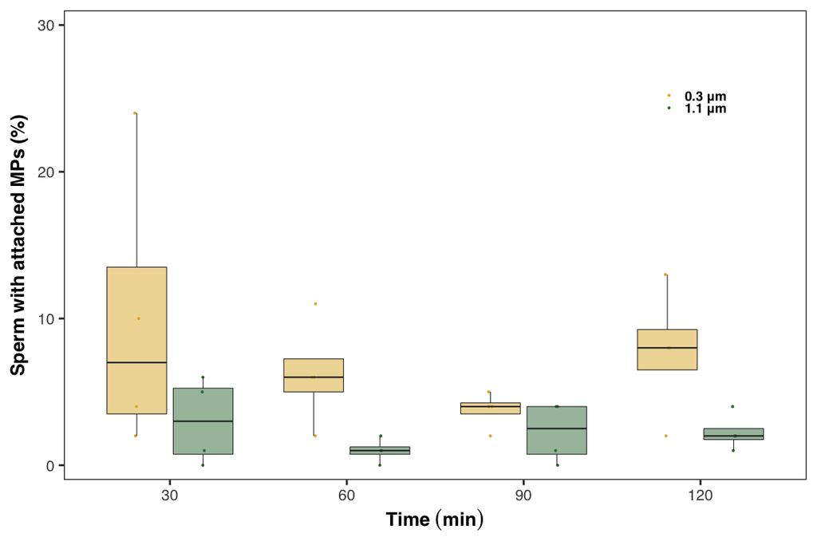

Figure S4 Boxplots depicting the percentage of sperm with attached MP beads over time as a function of MP bead size.

# Oocytes

The next step in the analyses was to assess the effects of MPs exposure on oocytes.

## Effects of MPs on maturation

The first step was to import the oocyte maturation data and carry out some basic data carpentry in order to get the data in the correct format for analysis.

```r
# Import the sperm motility data
data <- read.csv("Data/Oocyte_data.csv")

# Scale percentages between 0-1 for the binomial model
data$Percentage2 <- data$Percentage/100

# Rename the groups
data[which(data$Treatment == "CT"),"Treatment"] <- "Control"
data[which(data$Treatment == "B0.3"),"Treatment"] <- "MP_0.3"
data[which(data$Treatment == "B1.1"),"Treatment"] <- "MP_1.1"
data[which(data$Treatment == "B0.05"),"Treatment"] <- "MP_0.05"
data[which(data$Treatment == "B0.1"),"Treatment"] <- "MP_0.1"

#Convert to factors
data$Treatment <- as.factor(data$Treatment)
data$Nuclear_stage <- factor(data$Nuclear_stage, ordered = T, levels = c("BZP", "DG", "MT"))
data$replicate <- as.factor(data$Replicate)
```

After importing and preparing the data, the next step was to obtain some basic summary statistics.

```r
# Mean acrosomal integrity by treatment and time
means <- aggregate(Percentage2 ~ Nuclear_stage*Treatment, data = data, FUN = "mean")

# SDs by treatment and time
sds <- aggregate(Percentage2 ~ Nuclear_stage*Treatment, data = data, FUN = "sd")

means$SD <- sds$Percentage2
names(means)[3] <- c("Mean")

kable(means, format="markdown", digits = 3, align = "c", caption = "Basic summary statistics on the oocyte data.")
```

Basic summary statistics on the oocyte data.

| Nuclear_stage | Treatment | Mean | SD |
| --- | --- | --- | --- |
| BZP | Control | 0.044 | 0.052 |
| DG | Control | 0.275 | 0.123 |
| MT | Control | 0.681 | 0.103 |
| BZP | MP_0.3 | 0.214 | 0.076 |
| DG | MP_0.3 | 0.366 | 0.149 |
| MT | MP_0.3 | 0.420 | 0.148 |
| BZP | MP_1.1 | 0.262 | 0.109 |
| DG | MP_1.1 | 0.328 | 0.152 |
| MT | MP_1.1 | 0.410 | 0.176 |

After an initial visual verification, we found that we needed to assess whether there was any evidence of under/overdispersion in the data. This was done by estimating the dispersion parameter of the data.

```r
#Test if the data are under/overdispersed
quasi_binom <- glm(Percentage2 ~ Treatment + Nuclear_stage, data = data, family=quasibinomial)
summary(quasi_binom)
```

```
##
## Call:
## glm(formula = Percentage2 ~ Treatment + Nuclear_stage, family = quasibinomial,
##     data = data)
##
## Deviance Residuals:
##      Min        1Q    Median        3Q       Max
## -0.61689  -0.21810   0.00218   0.23649   0.59132
##
## Coefficients:
##                   Estimate Std. Error t value Pr(>|t|)
## (Intercept)     -7.627e-01  2.192e-01  -3.479  0.00152 **
## TreatmentMP_0.3  2.451e-04  3.071e-01   0.001  0.99937
## TreatmentMP_1.1  2.619e-12  3.071e-01   0.000  1.00000
## Nuclear_stage.L  1.116e+00  2.298e-01   4.855 3.26e-05 ***
## Nuclear_stage.Q -2.715e-02  2.166e-01  -0.125  0.90107
## ---
## Signif. codes:  0 '***' 0.001 '**' 0.01 '*' 0.05 '.' 0.1 ' ' 1
##
## (Dispersion parameter for quasibinomial family taken to be 0.115423)
##
##     Null deviance: 6.9459  on 35  degrees of freedom
## Residual deviance: 3.9141  on 31  degrees of freedom
## AIC: NA
##
## Number of Fisher Scoring iterations: 4
```

These results indicate that the dispersion parameter was 0.115.

### Mature cells

We used generalised linear regression models to assess the effects of MP exposure on the percentage of mature oocytes after a 24 hour maturation period. For these analyses all models had a quasi-binomial error distribution to account for the fact that the data were underdispersed percentages, ranging between 0 – 1. We also included random intercepts to account for any differences across replicates.

```r
MT.fit <- glmmPQL(Percentage2 ~ Treatment,
                  random = ~ 1|Replicate,
                  family=quasibinomial,
                  data = data[which(data$Nuclear_stage == "MT"),])

summary(MT.fit)
```

```
## Linear mixed-effects model fit by maximum likelihood
##   Data: data[which(data$Nuclear_stage == "MT"), ]
##   AIC BIC logLik
##    NA  NA     NA
##
## Random effects:
##  Formula: ~1 | Replicate
##         (Intercept)  Residual
## StdDev:   0.4982103 0.1177631
##
## Variance function:
##  Structure: fixed weights
##  Formula: ~invwt
## Fixed effects:  Percentage2 ~ Treatment
##                      Value Std.Error DF   t-value p-value
## (Intercept)      0.7966665 0.3245090  6  2.454990  0.0495
## TreatmentMP_0.3 -1.1398080 0.2068783  6 -5.509557  0.0015
## TreatmentMP_1.1 -1.1849105 0.2072735  6 -5.716653  0.0012
##  Correlation:
##                 (Intr) TMP_0.
## TreatmentMP_0.3 -0.338
## TreatmentMP_1.1 -0.337  0.533
##
## Standardized Within-Group Residuals:
##        Min         Q1        Med         Q3        Max
## -1.5253196 -0.5435709 -0.1934040  0.5956740  1.4625857
##
## Number of Observations: 12
## Number of Groups: 4
```

```r
# Tukey post-hoc test
MT.TUKEY <- glht(MT.fit,
                 mcp(Treatment = "Tukey"),
                 data = data[which(data$Nuclear_stage == "MT"),])
summary(MT.TUKEY)
```

```
##
##   Simultaneous Tests for General Linear Hypotheses
##
## Multiple Comparisons of Means: Tukey Contrasts
##
##
## Fit: glmmPQL(fixed = Percentage2 ~ Treatment, random = ~1 | Replicate,
##     family = quasibinomial, data = data[which(data$Nuclear_stage ==
##         "MT"), ])
##
## Linear Hypotheses:
##                       Estimate Std. Error z value Pr(>|z|)
## MP_0.3 - Control == 0  -1.1398     0.1792  -6.362   <1e-05 ***
## MP_1.1 - Control == 0  -1.1849     0.1795  -6.601   <1e-05 ***
## MP_1.1 - MP_0.3 == 0   -0.0451     0.1734  -0.260    0.963
## ---
## Signif. codes:  0 '***' 0.001 '**' 0.01 '*' 0.05 '.' 0.1 ' ' 1
## (Adjusted p values reported -- single-step method)
```

These results indicate that exposure to MPs resulted in significantly reduced oocyte maturation rates compared to the control. A Tukey post-hoc comparison found that while exposure to both the 0.3 $\mu\mathrm{m}$ and 1.1 $\mu\mathrm{m}$ MP beads resulted in significantly lower maturation rates than the control, there was no significant difference between the two sized beads.

### Degraded cells

We used generalised linear regression models to assess the effects of MP exposure on the percentage of degraded oocytes after a 24 hour maturation period. For these analyses all models had a quasi-binomial error distribution to account for the fact that the data were underdispersed percentages, ranging between 0 – 1. We also included random intercepts to account for any differences across replicates.

```r
DG.fit <- glmmPQL(Percentage2 ~ Treatment,
                  random = ~ 1|Replicate,
                  family=quasibinomial,
                  data = data[which(data$Nuclear_stage == "DG"),])

summary(DG.fit)
```

```
## Linear mixed-effects model fit by maximum likelihood
##   Data: data[which(data$Nuclear_stage == "DG"), ]
##   AIC BIC logLik
##    NA  NA     NA
##
## Random effects:
##  Formula: ~1 | Replicate
##         (Intercept)  Residual
## StdDev:   0.4841533 0.1373825
##
## Variance function:
##  Structure: fixed weights
##  Formula: ~invwt
## Fixed effects:  Percentage2 ~ Treatment
##                      Value Std.Error DF   t-value p-value
## (Intercept)     -1.0163720 0.3338075  6 -3.044785  0.0227
## TreatmentMP_0.3  0.4414409 0.2479213  6  1.780568  0.1253
## TreatmentMP_1.1  0.2655144 0.2507173  6  1.059019  0.3304
##  Correlation:
##                 (Intr) TMP_0.
## TreatmentMP_0.3 -0.400
## TreatmentMP_1.1 -0.395  0.531
##
## Standardized Within-Group Residuals:
##          Min           Q1          Med           Q3          Max
## -1.310939697 -0.618900428  0.008632261  0.521490568  1.799081925
##
## Number of Observations: 12
## Number of Groups: 4
```

```r
# Tukey post-hoc test
DG.TUKEY <- glht(DG.fit,
                 mcp(Treatment = "Tukey"),
                 data = data[which(data$Nuclear_stage == "DG"),])
summary(DG.TUKEY)
```

```
##
##   Simultaneous Tests for General Linear Hypotheses
##
## Multiple Comparisons of Means: Tukey Contrasts
##
##
## Fit: glmmPQL(fixed = Percentage2 ~ Treatment, random = ~1 | Replicate,
##     family = quasibinomial, data = data[which(data$Nuclear_stage ==
##         "DG"), ])
##
## Linear Hypotheses:
##                       Estimate Std. Error z value Pr(>|z|)
## MP_0.3 - Control == 0   0.4414     0.2147   2.056   0.0991 .
## MP_1.1 - Control == 0   0.2655     0.2171   1.223   0.4395
## MP_1.1 - MP_0.3 == 0   -0.1759     0.2092  -0.841   0.6775
## ---
## Signif. codes:  0 '***' 0.001 '**' 0.01 '*' 0.05 '.' 0.1 ' ' 1
## (Adjusted p values reported -- single-step method)
```

These results indicate that exposure to MPs tended to result in a higher percentage of degraded oocyte compared to the control, but the effects were not statistically significant. A Tukey post-hoc comparison found no evidence of any pair-wise differences.

### Broken zona pellucidae

We used generalised linear regression models to assess the effects of MP exposure on the percentage of oocytes with broken zona pellucidae after a 24 hour maturation period. For these analyses all models had a quasi-binomial error distribution to account for the fact that the data were underdispersed percentages, ranging between 0 – 1. We also included random intercepts to account for any differences across replicates.

```r
BZP.fit <- glmmPQL(Percentage2 ~ Treatment,
                   random = ~ 1|Replicate,
                   family=quasibinomial,
                   data = data[which(data$Nuclear_stage == "BZP"),])

summary(BZP.fit)
```

```
## Linear mixed-effects model fit by maximum likelihood
##   Data: data[which(data$Nuclear_stage == "BZP"), ]
##   AIC BIC logLik
##    NA  NA     NA
##
## Random effects:
##  Formula: ~1 | Replicate
##         (Intercept)  Residual
## StdDev:   0.3334861 0.1589298
##
## Variance function:
##  Structure: fixed weights
##  Formula: ~invwt
## Fixed effects:  Percentage2 ~ Treatment
##                     Value Std.Error DF   t-value p-value
## (Intercept)     -3.105634 0.4875155  6 -6.370330  0.0007
## TreatmentMP_0.3  1.782692 0.5006382  6  3.560839  0.0119
## TreatmentMP_1.1  2.053075 0.4941206  6  4.155007  0.0060
##  Correlation:
##                 (Intr) TMP_0.
## TreatmentMP_0.3 -0.820
## TreatmentMP_1.1 -0.831  0.808
##
## Standardized Within-Group Residuals:
##         Min          Q1         Med          Q3         Max
## -1.39173435 -0.81840743 -0.04819769  0.66010424  1.29451024
##
## Number of Observations: 12
## Number of Groups: 4
```

```r
# Tukey post-hoc test
BZP.TUKEY <- glht(BZP.fit,
                  mcp(Treatment = "Tukey"),
                  data = data[which(data$Nuclear_stage == "BZP"),])
summary(BZP.TUKEY)
```

```
##
##   Simultaneous Tests for General Linear Hypotheses
##
## Multiple Comparisons of Means: Tukey Contrasts
##
##
## Fit: glmmPQL(fixed = Percentage2 ~ Treatment, random = ~1 | Replicate,
##     family = quasibinomial, data = data[which(data$Nuclear_stage ==
##         "BZP"), ])
##
## Linear Hypotheses:
##                       Estimate Std. Error z value Pr(>|z|)
## MP_0.3 - Control == 0   1.7827     0.4336   4.112 0.000113 ***
## MP_1.1 - Control == 0   2.0531     0.4279   4.798  < 1e-05 ***
## MP_1.1 - MP_0.3 == 0    0.2704     0.2668   1.014 0.560600
## ---
## Signif. codes:  0 '***' 0.001 '**' 0.01 '*' 0.05 '.' 0.1 ' ' 1
## (Adjusted p values reported -- single-step method)
```

These results indicate that exposure to MPs resulted in a significantly higher percentage of oocytes with broken zona pellucidae after a 24 hour maturation period compared to the control. A Tukey post-hoc comparison found that while exposure to both the 0.3 $\mu\mathrm{m}$ and 1.1 $\mu\mathrm{m}$ MP beads resulted in significantly more broken zona pellucidae than the control, there was no significant difference in the number of broken zona pellucidae between the two size treatments. A figure of the results across all three metrics is shown below. Note: Here again the code used to generate the figure are not shown.

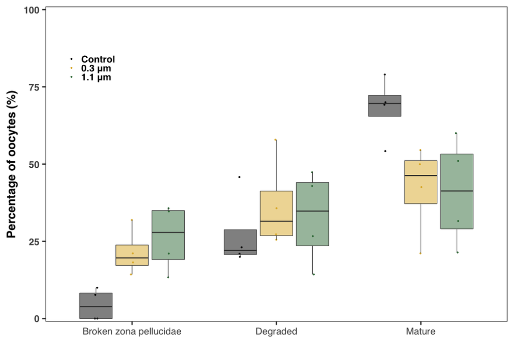

Figure S5 Boxplots depicting oocyte mature over time as a function of microplastics treatment.

### MP presence in follicular fluids

We also wanted to visualise the different plastic polymers that were identified in bovine follicular fluid samples. Each of these samples came from a pool of follicular fluid collected from different cows, with each sample belonging to a different collection period.

```r
# Import the plastic particle data
data <- read.csv("Data/General numbers2.csv")
data <- data[-which(data$Classification == "Non-plastic related"),]
data2 <- read.csv("Data/MP_fluids.csv")
```

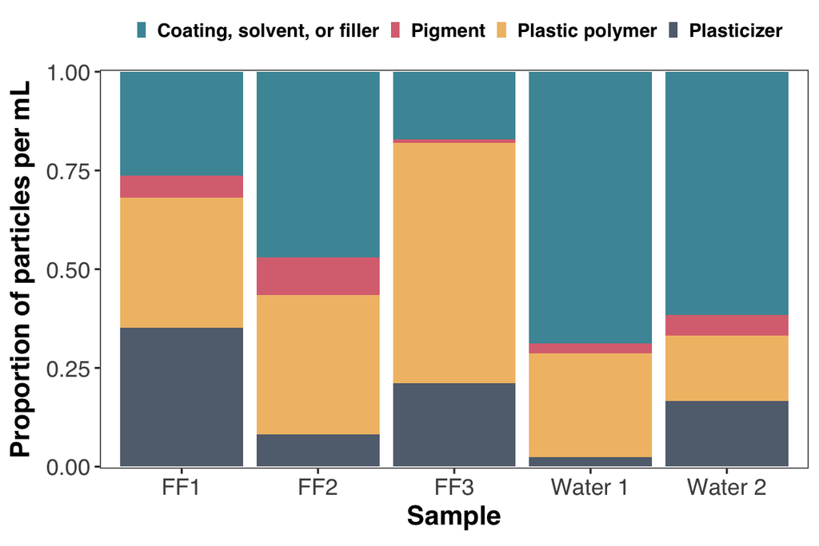

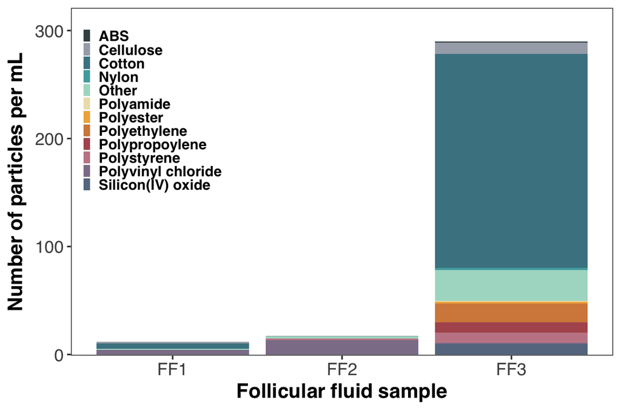

Figure S6 Bar chart depicting the number of plastic particles found in cow follicular fluid samples.

## Proteomics

### Data scaling

The first step was to transform the raw data so that they would be on the same scale. To render the data comparable across species and developmental stages, data were scaled using Probabilistic Quotient Normalisation (PQN; Dieterle et al. 2006), which calibrates individual gene expression profiles against the median profile. Notably, analyses on PQN transformed data have been shown to have low false-positive rates, and can accurately recover groups of interest without introducing artefactual differences (Noonan et al. 2018).

```r
#Load in the packages
library(FactoMineR)
library(ggplot2)
library(ellipse)
library(randomForest)
library(caret)
library(ggridges)
library(viridis)
library(gridExtra)
library(limma)


#Import the raw data
data <- read.csv("Data/Proteomics_oocyte_MP_raw.csv")

# Some data carpentry
# Only keep a single one of the multiple IDs
data$Protein.IDs <- sub(";.*", "", data$Protein.IDs)
Proteins <- data$Protein.IDs


#Identify the gene names
GN <- sub(".*GN=", "", data$Fasta.headers)
GN <-  sub(" .*", "", GN)
GN[grepl( 'tr|', GN, fixed = TRUE)] <- NA
data$Gene_Name <- GN

#Store the proteins expressed within the different groups
control <- rowMeans(data[,c("CT_1","CT_2","CT_3","CT_4","CT_5")])
B0.3 <- rowMeans(data[,c("B0.3_1","B0.3_2","B0.3_3","B0.3_4","B0.3_5")])
B1.1 <- rowMeans(data[,c("B1.1_1","B1.1_2","B1.1_3","B1.1_4","B1.1_5")])

#Transpose the data and assign the correct column names
data <- data.frame(t(data[,c(7:21)]))
colnames(data) <- Proteins

#Store the untransformed data in memory
raw_data <- data


# Create vectors with treatment IDs
Treatment <- c("1.1", "1.1", "1.1", "control", "0.3", "0.3", "0.3", "1.1", "control", "control", "0.3", "0.3", "control", "control", "1.1")
Treatment <- as.factor(Treatment)

Treatment_2 <- c("MP", "MP", "MP", "control", "MP", "MP", "MP", "MP", "control", "control", "MP", "MP", "control", "control", "MP")
Treatment_2 <- as.factor(Treatment_2)

###############################################################
# PQN Normalisation of the data
###############################################################

#Calculate the median of each gene's expression to generate a reference sample
ref <- as.vector(apply(data, 2, median))

for(i in 1:nrow(data)){
  QUOTIENTS <- data[i,]/ref
  m_j <- median(t(QUOTIENTS), na.rm = T)
  data[i,] <- data[i,]/m_j
  data[i,][data[i,] == min(data[i,])] <- 0
}
```

### Random Forest Classification

After the data were transformed, a random forest (RF) model was used to classify protein expression profiles according to whether or not the oocytes were exposed to microplastics, with scaled gene expression values as the prediction variables. This allowed us to determine how well information contained within the proteomics data could be used to predict MP exposure. These analyses were conducted using the R package randomForest (RColorBrewer and Liaw, 2018). We chose RF modeling as it does not require any parameter reduction prior to analysis (Cutler et al. 2007). Identification of genes important for classifying groups of interest in each RF model was carried out using RF variable importance values.

```r
#Create a dataset that has information on MP exposure vs. controls
Treatment_Data <- data
Treatment_Data$Treatment <- Treatment


#Run the random forest model identifying MP exposure treatments
exposure.mod <- randomForest(y = Treatment_Data$Treatment,
                              x = Treatment_Data[, colnames(Treatment_Data) != "Treatment"],
                              mtry =  5,
                              ntree= 20000,
                              importance=TRUE,
                              proximity = TRUE,
                              keep.forest=TRUE,
                              replace = TRUE)

exposure.mod
```

```
##
## Call:
##  randomForest(x = Treatment_Data[, colnames(Treatment_Data) !=      "Treatment"], y = Treatment_Data$Treatment, ntree = 20000,      mtry = 5, replace = TRUE, importance = TRUE, proximity = TRUE,      keep.forest = TRUE)
##                Type of random forest: classification
##                      Number of trees: 20000
## No. of variables tried at each split: 5
##
##         OOB estimate of  error rate: 80%
## Confusion matrix:
##         0.3 1.1 control class.error
## 0.3       1   1       3         0.8
## 1.1       2   1       2         0.8
## control   3   1       1         0.8
```

```r
confusionMatrix(exposure.mod$predicted, Treatment_Data$Treatment)
```

```
## Confusion Matrix and Statistics
##
##           Reference
## Prediction 0.3 1.1 control
##    0.3       1   2       3
##    1.1       1   1       1
##    control   3   2       1
##
## Overall Statistics
##
##                Accuracy : 0.2
##                  95% CI : (0.0433, 0.4809)
##     No Information Rate : 0.3333
##     P-Value [Acc > NIR] : 0.9206
##
##                   Kappa : -0.2
##
##  Mcnemar's Test P-Value : 0.8810
##
## Statistics by Class:
##
##                      Class: 0.3 Class: 1.1 Class: control
## Sensitivity             0.20000    0.20000        0.20000
## Specificity             0.50000    0.80000        0.50000
## Pos Pred Value          0.16667    0.33333        0.16667
## Neg Pred Value          0.55556    0.66667        0.55556
## Prevalence              0.33333    0.33333        0.33333
## Detection Rate          0.06667    0.06667        0.06667
## Detection Prevalence    0.40000    0.20000        0.40000
## Balanced Accuracy       0.35000    0.50000        0.35000
```

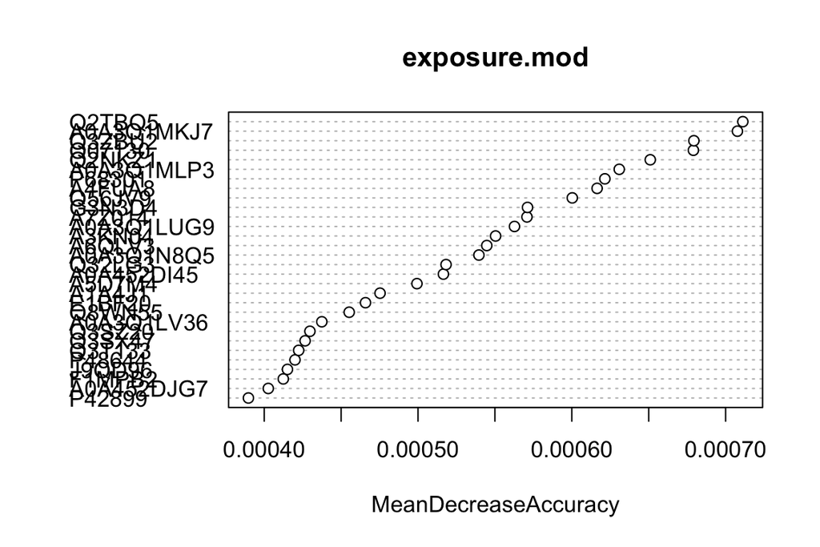

```r
varImpPlot(exposure.mod, type=1, scale = FALSE)
```

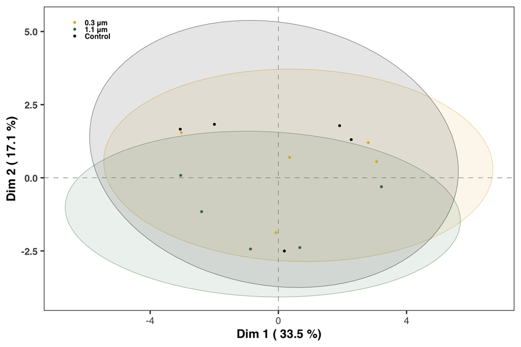

Figure S7 PCA on the proximity matrix of the RF classification model.

```
##  [1] "Q2TBQ5"     "A0A3Q1MKJ7" "Q3ZBU2"     "Q07130"     "Q2NKZ1"
##  [6] "A0A3Q1MLP3" "P68301"     "A4FUA8"     "Q56JV9"     "G3N3D4"
## [11] "A7Z014"     "A0A3Q1LUG9" "A3KN04"     "A6QLV3"     "A0A3Q1N8Q5"
## [16] "Q32LG3"     "A0A452DI45" "A5D7M4"     "A1A4J1"     "E1BF20"
```

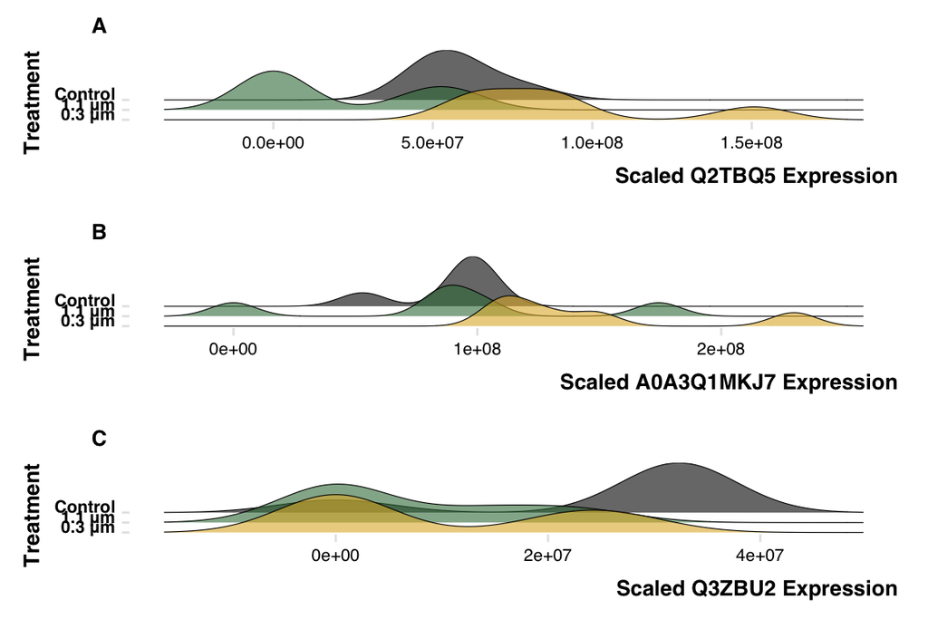

Figure S8 Density plots of the variables of primary importance for predicting MP exposure.

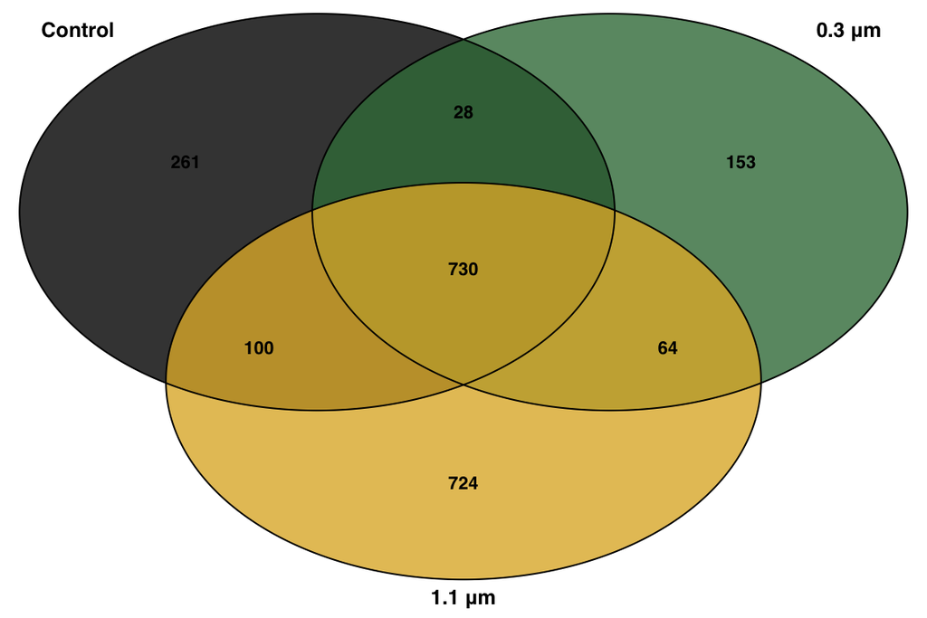

Figure S9 Venn diagram of the proteins expressed within the different groups.

## Differentially Expressed Proteins (DEPs)

Differentially expressed proteins (DEPs) of normalized data were identified using the R package `limma`. An adjusted p-value to correct for multiple testing was calculated using the Benjamini–Hochberg method. The most widely used correction for genomic studies is the Benjamini-Hochberg (BH) correction, that aims to control the FDR across significant genes.

```r
#Convert to a numeric matrix and log transform
DATA <- as.matrix(t(data))
DATA <- log(DATA + 1)
DATA <- DATA[,-4]

#Create the design matrix
design <- cbind(Exposure = as.numeric(Treatment_2)[-4],
                Treatment = as.numeric(Treatment)[-4])


#Run the analysis and compile the results
test <- lmFit(DATA, design = model.matrix(~ 1 + design[,1]))
test2 <- eBayes(test)
test3 <- topTable(test2, number = length(test2$coefficients), sort.by = "none")
```

```
## Removing intercept from test coefficients
```

```r
#Which proteins are differentially expressed
GN[which(test3$adj.P.Val < 0.05)]
```

```
## [1] "SHOC2"
```

```r
GN[which(test3$P.Val < 0.05)]
```

```
##  [1] "C9"       "RAB2A"    "CYC1"     "SH3BGRL3" "CXNK1"    "SLC25A15"
##  [7] "FHIT"     "SPCS2"    "HK1"      "SHOC2"    "IPO5"     "RAB21"
## [13] "BLMH"     "TXNDC17"  "RPL13A"   "CKB"      "TUBG1"    "PGM3"
## [19] "RAB6B"    ""         "GDI1"     "KCTD12"   "ECI2"     "GTSF1"
## [25] "LTBP1"    "ARF4"     ""         "TMED9"    "MYDGF"    "RPN2"
## [31] NA         "SAFB"     "PDCD6IP"  "CAPZA1"   "ACCSL"
```

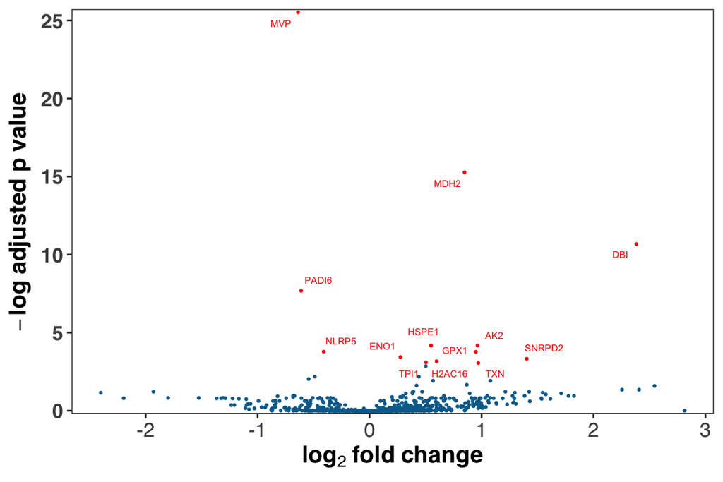

Figure S10 Volcano plot of the proteomics analysis comparing oocytes exposed to 0.3 μm MPs vs the controls.

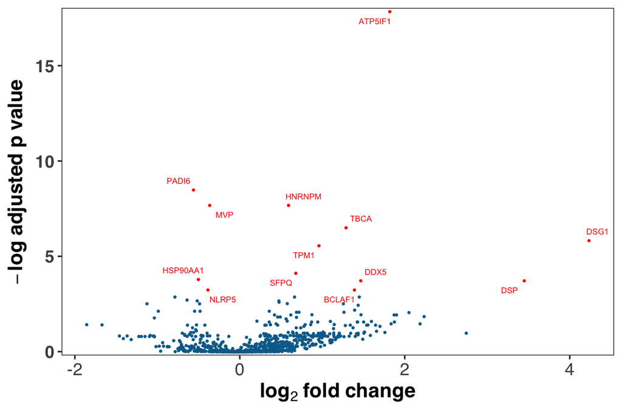

Figure S11 Volcano plot of the proteomics analysis comparing oocytes exposed to 1.1 μm MPs vs the controls.

```r
write.csv(test3, file = "Results/DEPs.csv")
```